# Testing affect regulation via computational modeling of real-time alcohol choices in daily life — Sensitivity Analyses: Choice Proportion

2026-06-13

# 1 About This Report

This report presents the **sensitivity analyses** for **Choice Proportion** (choice_prop). These analyses re-estimate the primary models, but replace the *current* affective state used as the focal predictor in the main analyses with two alternative classes of affective predictor:

1. **Expected change in the affective state following alcohol use** — participants’ prospective ratings of how consuming alcohol would change their stress / negative affect / positive affect (stores `stress_change_alc`, `na_change_alc`, `pa_change_alc`).
2. **Perceived change in the affective state vs. the last EMA assessment** — participants’ reported change in stress / negative affect / positive affect relative to their previous assessment (stores `perceived_stress_change`, `perceived_na_change`, `perceived_pa_change`).

This gives six focal predictors in total. The modeling pipeline is otherwise identical to the primary analyses; the goal is to check whether the main conclusions hold under these alternative operationalizations of affective state. The focal predictor for each model is detected automatically from the fitted model formula.

For each focal predictor, the report is organized as follows:

- **Dimensionality reduction:** PCA and UMAP component composition tables, showing which raw variables load most strongly onto each component.
- **GLMM results (raw features):** Summary of results from GLMM model with raw variables.
- **Random forest results (raw features):** Summary of results from random forest model with raw variables.
- **Model comparison:** RMSE comparison table across all methods (GLMM, random forest, decision tree) and feature sets (raw, PCA, UMAP).

# 2 Expected Stress Change (with alcohol) (stress_change_alc)

## 2.1 Dimensionality Reduction

- **PCA components (80% variance, max 5):** 5
- **UMAP components (matching PCA):** 5

### 2.1.1 PCA Component Composition (top 5 correlated variables)

**PC_1**

| Variable | Correlation |
| --- | --- |
| alc_exp_energeticYes | -0.576 |
| alc_exp_better_moodYes | -0.557 |
| alc_exp_sociableYes | -0.547 |
| alc_exp_buzzYes | -0.502 |
| alc_craving | -0.487 |

**PC_2**

| Variable | Correlation |
| --- | --- |
| alc_exp_injuryYes | -0.596 |
| alc_exp_be_rudeYes | -0.593 |
| alc_exp_embarrassedYes | -0.578 |
| alc_exp_nauseous_vomitYes | -0.491 |
| alc_exp_hangoverYes | -0.467 |

**PC_3**

| Variable | Correlation |
| --- | --- |
| locationschool_work | 0.591 |
| alc_today | -0.578 |
| alc_cuenone | 0.568 |
| time_of_dayevening | -0.476 |
| locationhome | -0.458 |

**PC_4**

| Variable | Correlation |
| --- | --- |
| soft_yday | 0.697 |
| soft_today | 0.649 |
| soft_intend | 0.634 |
| soft_craving | 0.488 |
| alc_exp_embarrassedYes | -0.389 |

**PC_5**

| Variable | Correlation |
| --- | --- |
| locationhome | -0.632 |
| social_context_aloneYes | -0.561 |
| social_context_friend_roommateYes | 0.501 |
| social_context_strangerYes | 0.417 |
| locationsomeone_elses_home | 0.372 |

### 2.1.2 UMAP Component Composition (top 5 correlated variables)

**UMAP_1**

| Variable | Correlation |
| --- | --- |
| alc_exp_embarrassedYes | 0.297 |
| alc_exp_be_rudeYes | 0.293 |
| alc_craving | 0.223 |
| alc_intend | 0.163 |
| alc_mot_copingYes | 0.135 |

**UMAP_2**

| Variable | Correlation |
| --- | --- |
| alc_yday | -0.321 |
| alc_intend | -0.155 |
| alc_mot_enhanceYes | -0.127 |
| soft_yday | 0.109 |
| alc_exp_embarrassedYes | 0.105 |

**UMAP_3**

| Variable | Correlation |
| --- | --- |
| alc_today | -0.411 |
| alc_yday | -0.410 |
| alc_cuenone | 0.179 |
| alc_intend | -0.159 |
| soft_craving | 0.145 |

**UMAP_4**

| Variable | Correlation |
| --- | --- |
| soft_yday | 0.772 |
| soft_today | 0.661 |
| soft_intend | 0.555 |
| soft_craving | 0.284 |
| alc_exp_be_rudeYes | 0.168 |

**UMAP_5**

| Variable | Correlation |
| --- | --- |
| alc_exp_injuryYes | 0.514 |
| alc_exp_embarrassedYes | 0.385 |
| alc_exp_be_rudeYes | 0.382 |
| alc_exp_nauseous_vomitYes | 0.360 |
| alc_exp_energeticYes | 0.228 |

## 2.2 GLMM Results

### 2.2.1 Raw Features

- **Optimal lambda:** 80 (index 5 of 21)
- **CV RMSE:** 0.2815

**Non-zero coefficients** (focal predictor terms highlighted):

| Term | Estimate | Category |
| --- | --- | --- |
| (Intercept) | 0.2979 | Intercept |
| stress_change_alc | -0.0051 | Focal predictor |
| alc_cuenone | -0.0150 | Covariate main effect |
| alc_craving | 0.0140 | Covariate main effect |
| alc_exp_nauseous_vomitYes | -0.0127 | Covariate main effect |
| alc_exp_relaxedYes | 0.0117 | Covariate main effect |
| alc_mot_enhanceYes | 0.0083 | Covariate main effect |
| time_of_dayevening | 0.0070 | Covariate main effect |
| alc_exp_better_moodYes | 0.0066 | Covariate main effect |
| alc_exp_buzzYes | 0.0062 | Covariate main effect |
| alc_intend | 0.0055 | Covariate main effect |
| alc_today | 0.0041 | Covariate main effect |
| alc_mot_copingYes | 0.0030 | Covariate main effect |
| soft_intend | -0.0029 | Covariate main effect |
| soft_craving | -0.0028 | Covariate main effect |
| social_context_romantic_partnerYes | 0.0019 | Covariate main effect |
| social_context_familyYes | -0.0012 | Covariate main effect |
| alc_yday | 0.0011 | Covariate main effect |
| soft_yday | -0.0009 | Covariate main effect |
| alc_exp_energeticYes | 0.0006 | Covariate main effect |
| bored_state | 0.0004 | Covariate main effect |
| alc_exp_hangoverYes | 0.0002 | Covariate main effect |
| thirst_state | 0.0001 | Covariate main effect |
| alc_exp_injuryYes | 0.0001 | Covariate main effect |
| social_context_friend_roommateYes | 0.0001 | Covariate main effect |
| time_of_dayevening:stress_change_alc | -0.0115 | Interaction with focal predictor |
| alc_exp_embarrassedYes:stress_change_alc | -0.0078 | Interaction with focal predictor |
| alc_exp_nauseous_vomitYes:stress_change_alc | -0.0072 | Interaction with focal predictor |
| alc_exp_hangoverYes:stress_change_alc | -0.0059 | Interaction with focal predictor |
| alc_exp_be_rudeYes:stress_change_alc | -0.0055 | Interaction with focal predictor |
| locationhome:stress_change_alc | -0.0053 | Interaction with focal predictor |
| alc_craving:stress_change_alc | -0.0050 | Interaction with focal predictor |
| alc_exp_buzzYes:stress_change_alc | -0.0050 | Interaction with focal predictor |
| social_context_romantic_partnerYes:stress_change_alc | -0.0050 | Interaction with focal predictor |
| alc_mot_copingYes:stress_change_alc | -0.0049 | Interaction with focal predictor |
| responsibilityYes:stress_change_alc | -0.0042 | Interaction with focal predictor |
| alc_exp_relaxedYes:stress_change_alc | -0.0041 | Interaction with focal predictor |
| alc_exp_better_moodYes:stress_change_alc | -0.0040 | Interaction with focal predictor |
| alc_exp_energeticYes:stress_change_alc | -0.0038 | Interaction with focal predictor |
| social_context_aloneYes:stress_change_alc | -0.0037 | Interaction with focal predictor |
| alc_exp_injuryYes:stress_change_alc | -0.0035 | Interaction with focal predictor |
| alc_mot_enhanceYes:stress_change_alc | -0.0032 | Interaction with focal predictor |
| thirst_state:stress_change_alc | -0.0020 | Interaction with focal predictor |
| alc_intend:stress_change_alc | -0.0019 | Interaction with focal predictor |
| bored_state:stress_change_alc | -0.0019 | Interaction with focal predictor |
| alc_cuenone:stress_change_alc | -0.0018 | Interaction with focal predictor |
| tired_state:stress_change_alc | -0.0017 | Interaction with focal predictor |
| alc_today:stress_change_alc | -0.0016 | Interaction with focal predictor |
| soft_today:stress_change_alc | -0.0016 | Interaction with focal predictor |
| soft_yday:stress_change_alc | -0.0009 | Interaction with focal predictor |
| alc_exp_sociableYes:stress_change_alc | -0.0007 | Interaction with focal predictor |
| alc_yday:stress_change_alc | -0.0006 | Interaction with focal predictor |
| social_context_familyYes:stress_change_alc | -0.0006 | Interaction with focal predictor |
| day_of_weekWed:stress_change_alc | -0.0006 | Interaction with focal predictor |
| soft_craving:stress_change_alc | 0.0005 | Interaction with focal predictor |
| hunger_state:stress_change_alc | -0.0004 | Interaction with focal predictor |
| locationother:stress_change_alc | -0.0002 | Interaction with focal predictor |
| social_context_friend_roommateYes:stress_change_alc | 0.0002 | Interaction with focal predictor |
| alc_cueindirectly_visible:stress_change_alc | 0.0002 | Interaction with focal predictor |
| day_of_weekTue:stress_change_alc | -0.0002 | Interaction with focal predictor |
| alc_mot_socialYes:stress_change_alc | -0.0001 | Interaction with focal predictor |
| locationschool_work:stress_change_alc | 0.0001 | Interaction with focal predictor |
| day_of_weekMon:stress_change_alc | 0.0001 | Interaction with focal predictor |
| day_of_weekSat:stress_change_alc | 0.0001 | Interaction with focal predictor |
| day_of_weekSun:stress_change_alc | 0.0001 | Interaction with focal predictor |

- 33 coefficients penalized to zero.*

#### 2.2.1.1 Predicted vs. Observed

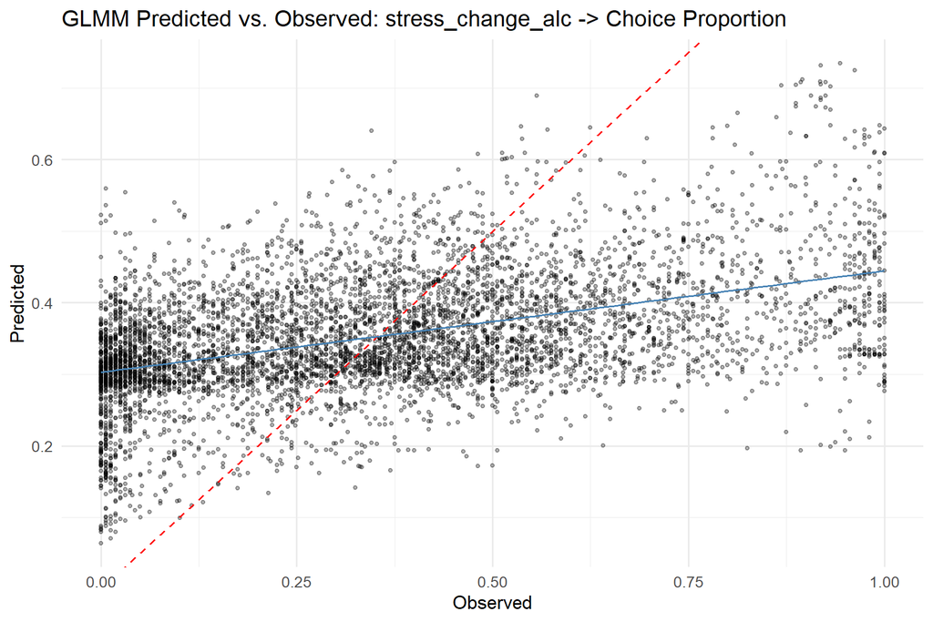

#### 2.2.1.2 Residual Diagnostics

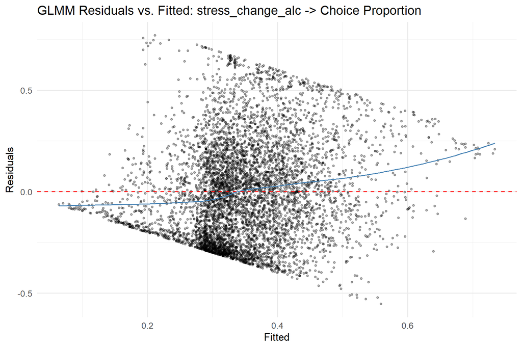

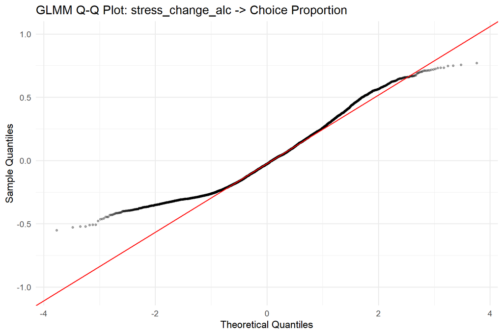

### 2.2.2 PCA Features

- **Optimal lambda:** 85 (index 4 of 21)
- **CV RMSE:** 0.292

**Non-zero coefficients:**

| Term | Estimate |
| --- | --- |
| (Intercept) | 0.3382 |
| PC_1 | -0.0273 |
| PC_2 | 0.0431 |
| PC_3 | -0.0516 |
| stress_change_alc | -0.0321 |
| PC_1:stress_change_alc | 0.0028 |
| PC_3:stress_change_alc | 0.0057 |
| PC_5:stress_change_alc | 0.0075 |

- 4 coefficients penalized to zero.*

### 2.2.3 UMAP Features

- **Optimal lambda:** 100 (index 1 of 21)
- **CV RMSE:** 0.284

**Non-zero coefficients:**

| Term | Estimate |
| --- | --- |
| (Intercept) | 0.3319 |
| UMAP_1 | 0.0023 |
| UMAP_2 | -0.0059 |
| UMAP_3 | -0.0059 |
| UMAP_4 | -0.0122 |
| UMAP_5 | 0.0108 |
| stress_change_alc | -0.0543 |
| UMAP_1:stress_change_alc | 0.0003 |
| UMAP_5:stress_change_alc | -0.0127 |

- 3 coefficients penalized to zero.*

## 2.3 Random Forest Results (Raw)

### 2.3.1 Tuning Summary

- **mtry:** 14
- **min.node.size:** 3
- **sample.fraction:** 0.863
- **CV RMSE:** 0.1907

### 2.3.2 Variable Importance (Permutation)

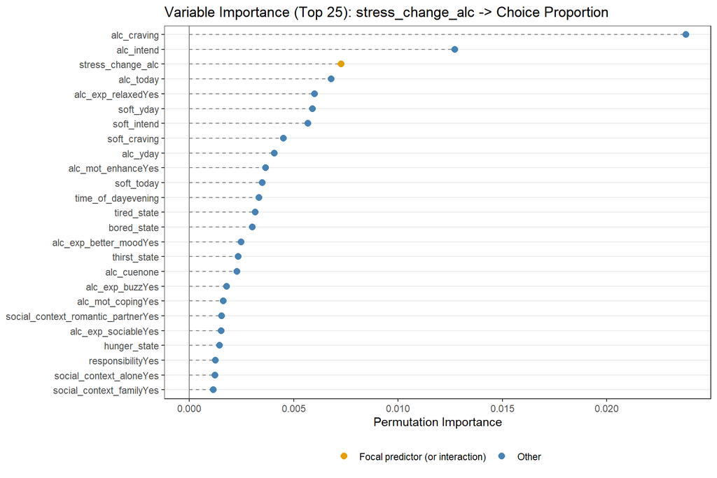

**Full importance ranking:**

| Variable | Importance |
| --- | --- |
| alc_craving | 0.023787 |
| alc_intend | 0.012709 |
| stress_change_alc | 0.007262 |
| alc_today | 0.006786 |
| alc_exp_relaxedYes | 0.006004 |
| soft_yday | 0.005891 |
| soft_intend | 0.005679 |
| soft_craving | 0.004513 |
| alc_yday | 0.004070 |
| alc_mot_enhanceYes | 0.003657 |
| soft_today | 0.003504 |
| time_of_dayevening | 0.003331 |
| tired_state | 0.003165 |
| bored_state | 0.003013 |
| alc_exp_better_moodYes | 0.002487 |
| thirst_state | 0.002350 |
| alc_cuenone | 0.002281 |
| alc_exp_buzzYes | 0.001791 |
| alc_mot_copingYes | 0.001631 |
| social_context_romantic_partnerYes | 0.001545 |
| alc_exp_sociableYes | 0.001529 |
| hunger_state | 0.001454 |
| responsibilityYes | 0.001259 |
| social_context_aloneYes | 0.001236 |
| social_context_familyYes | 0.001147 |
| locationhome | 0.000655 |
| locationschool_work | 0.000644 |
| alc_exp_embarrassedYes | 0.000586 |
| alc_exp_hangoverYes | 0.000574 |
| alc_exp_energeticYes | 0.000490 |
| alc_exp_nauseous_vomitYes | 0.000476 |
| alc_mot_socialYes | 0.000430 |
| alc_exp_be_rudeYes | 0.000345 |
| alc_exp_injuryYes | 0.000197 |
| locationother | 0.000144 |
| social_context_friend_roommateYes | 0.000134 |
| alc_cueindirectly_visible | 0.000059 |
| locationsomeone_elses_home | 0.000058 |
| social_context_coworker_classmateYes | 0.000049 |
| social_context_strangerYes | 0.000047 |
| locationrestaurant_cafe | 0.000019 |
| locationoutdoors | 0.000017 |
| social_context_otherYes | 0.000017 |
| day_of_weekSat | 0.000011 |
| day_of_weekSun | 0.000002 |
| day_of_weekWed | -0.000062 |
| day_of_weekThu | -0.000067 |
| day_of_weekMon | -0.000072 |
| day_of_weekTue | -0.000084 |

### 2.3.3 Partial Dependence Plots

PDP for the focal predictor and the top 5 most important non-interaction covariates.

#### 2.3.3.1 Focal Predictor: stress_change_alc

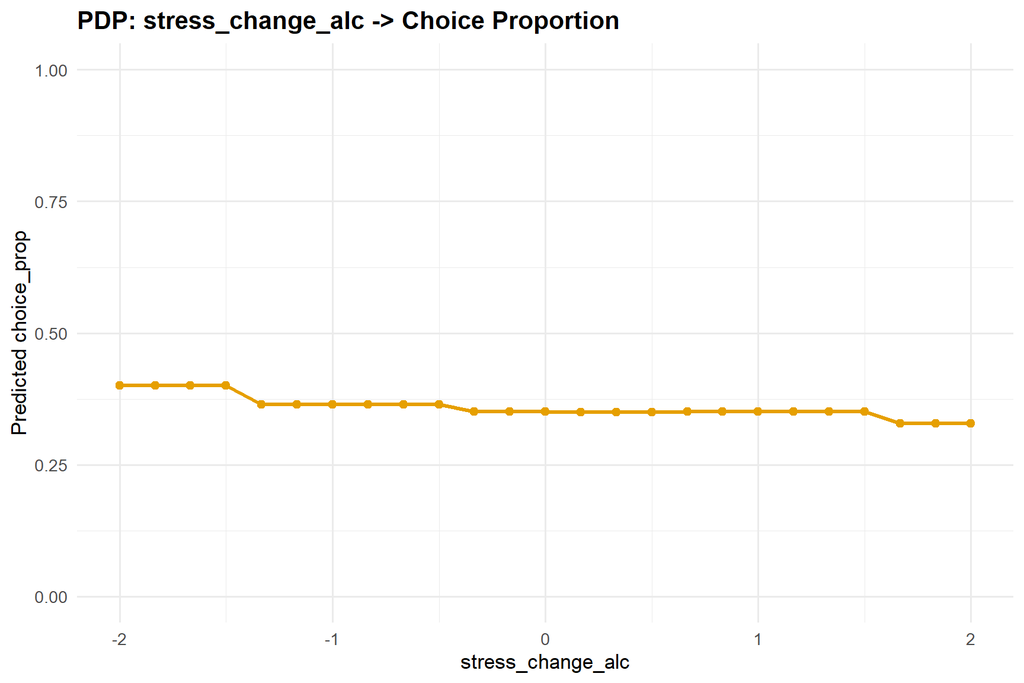

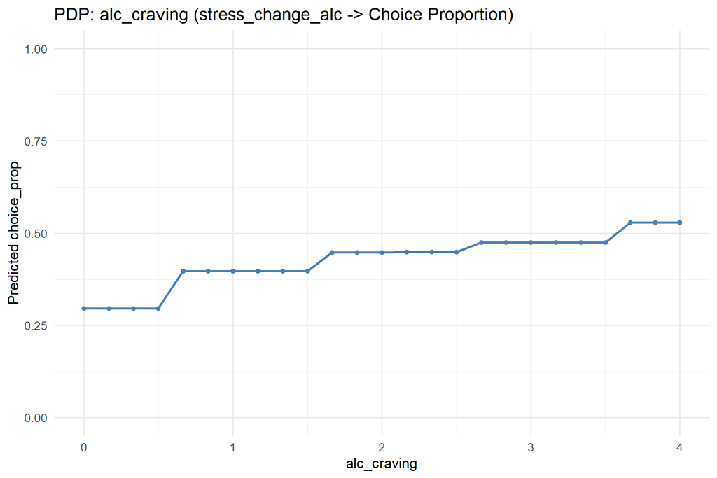

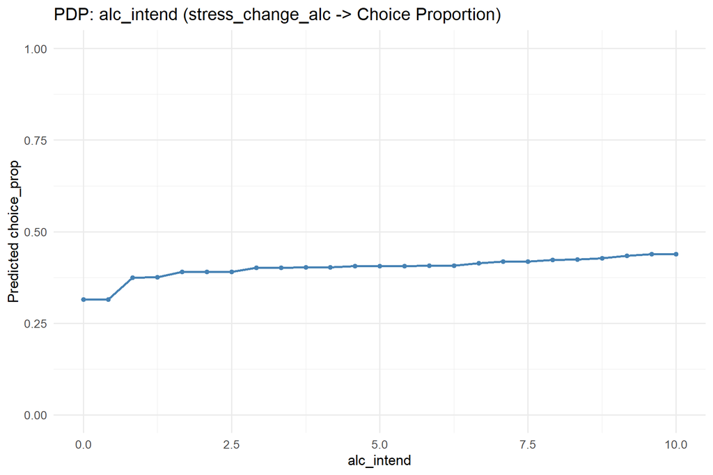

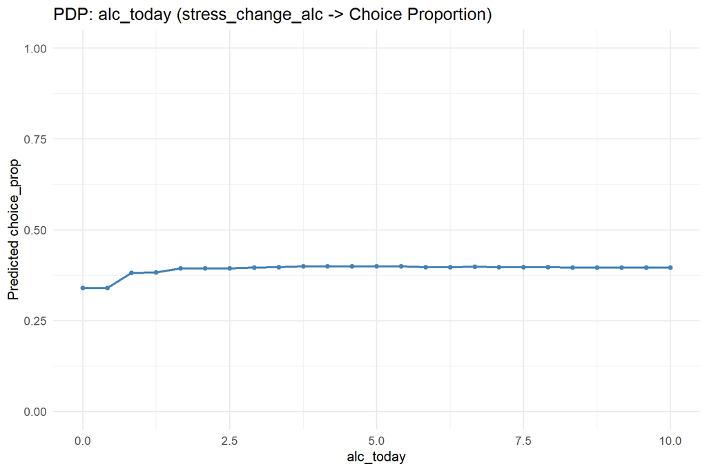

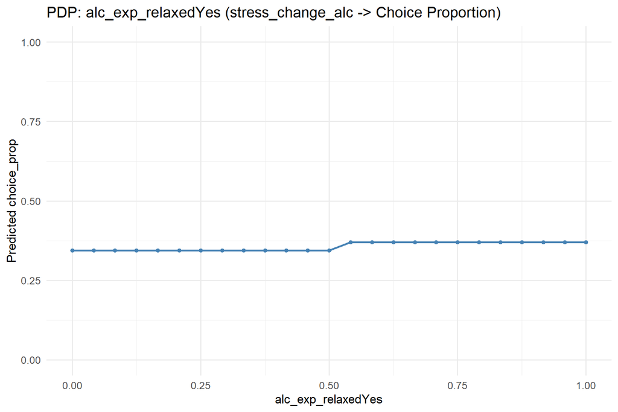

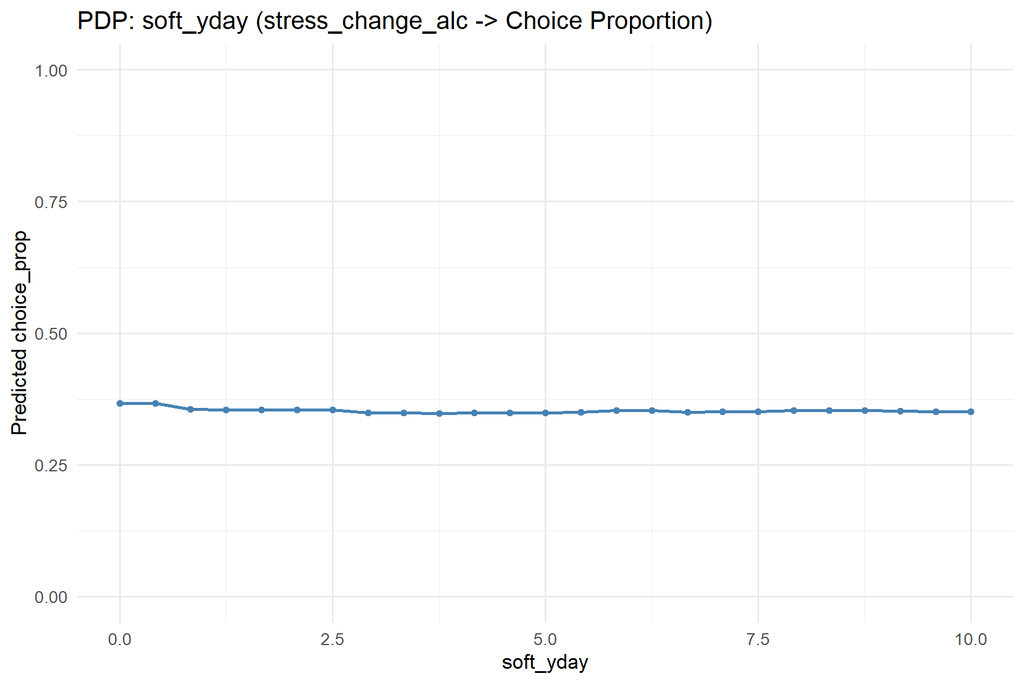

### 2.3.4 Predicted vs. Observed

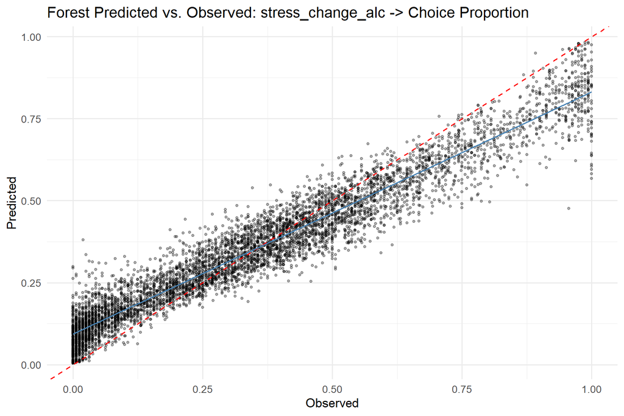

## 2.4 Model Comparison

### 2.4.1 RMSE Comparison (all methods and feature sets)

| Method | Raw | PCA | UMAP |
| --- | --- | --- | --- |
| glmm | 0.2815 | 0.2920 | 0.284 |
| forest | 0.1907 | 0.2303 | 0.212 |
| tree | 0.2465 | 0.2611 | 0.261 |

# 3 Expected Negative Affect Change (with alcohol) (NA_change_alc)

## 3.1 Dimensionality Reduction

- **PCA components (80% variance, max 5):** 5
- **UMAP components (matching PCA):** 5

### 3.1.1 PCA Component Composition (top 5 correlated variables)

**PC_1**

| Variable | Correlation |
| --- | --- |
| alc_exp_energeticYes | -0.576 |
| alc_exp_better_moodYes | -0.557 |
| alc_exp_sociableYes | -0.547 |
| alc_exp_buzzYes | -0.503 |
| alc_craving | -0.487 |

**PC_2**

| Variable | Correlation |
| --- | --- |
| alc_exp_injuryYes | -0.596 |
| alc_exp_be_rudeYes | -0.594 |
| alc_exp_embarrassedYes | -0.579 |
| alc_exp_nauseous_vomitYes | -0.491 |
| alc_exp_hangoverYes | -0.468 |

**PC_3**

| Variable | Correlation |
| --- | --- |
| locationschool_work | 0.590 |
| alc_today | -0.578 |
| alc_cuenone | 0.568 |
| time_of_dayevening | -0.476 |
| locationhome | -0.457 |

**PC_4**

| Variable | Correlation |
| --- | --- |
| soft_yday | 0.700 |
| soft_today | 0.650 |
| soft_intend | 0.634 |
| soft_craving | 0.488 |
| alc_exp_embarrassedYes | -0.388 |

**PC_5**

| Variable | Correlation |
| --- | --- |
| locationhome | -0.632 |
| social_context_aloneYes | -0.560 |
| social_context_friend_roommateYes | 0.500 |
| social_context_strangerYes | 0.417 |
| locationsomeone_elses_home | 0.371 |

### 3.1.2 UMAP Component Composition (top 5 correlated variables)

**UMAP_1**

| Variable | Correlation |
| --- | --- |
| alc_intend | 0.337 |
| alc_yday | 0.320 |
| alc_craving | 0.312 |
| alc_exp_embarrassedYes | 0.278 |
| alc_exp_be_rudeYes | 0.275 |

**UMAP_2**

| Variable | Correlation |
| --- | --- |
| alc_yday | -0.281 |
| alc_exp_embarrassedYes | 0.210 |
| alc_exp_be_rudeYes | 0.207 |
| soft_yday | 0.129 |
| alc_mot_enhanceYes | -0.121 |

**UMAP_3**

| Variable | Correlation |
| --- | --- |
| alc_yday | -0.385 |
| alc_today | -0.328 |
| soft_craving | 0.207 |
| thirst_state | 0.185 |
| alc_exp_be_rudeYes | 0.178 |

**UMAP_4**

| Variable | Correlation |
| --- | --- |
| soft_yday | 0.809 |
| soft_today | 0.714 |
| soft_intend | 0.575 |
| soft_craving | 0.301 |
| alc_exp_be_rudeYes | 0.141 |

**UMAP_5**

| Variable | Correlation |
| --- | --- |
| alc_exp_injuryYes | 0.494 |
| alc_exp_nauseous_vomitYes | 0.354 |
| alc_exp_embarrassedYes | 0.343 |
| alc_exp_be_rudeYes | 0.340 |
| alc_exp_energeticYes | 0.195 |

## 3.2 GLMM Results

### 3.2.1 Raw Features

- **Optimal lambda:** 80 (index 5 of 21)
- **CV RMSE:** 0.2816

**Non-zero coefficients** (focal predictor terms highlighted):

| Term | Estimate | Category |
| --- | --- | --- |
| (Intercept) | 0.3048 | Intercept |
| NA_change_alc | -0.0052 | Focal predictor |
| alc_cuenone | -0.0161 | Covariate main effect |
| alc_craving | 0.0153 | Covariate main effect |
| alc_exp_nauseous_vomitYes | -0.0140 | Covariate main effect |
| alc_exp_relaxedYes | 0.0130 | Covariate main effect |
| alc_mot_enhanceYes | 0.0091 | Covariate main effect |
| alc_exp_better_moodYes | 0.0078 | Covariate main effect |
| time_of_dayevening | 0.0075 | Covariate main effect |
| alc_exp_buzzYes | 0.0072 | Covariate main effect |
| alc_intend | 0.0060 | Covariate main effect |
| alc_mot_copingYes | 0.0044 | Covariate main effect |
| alc_today | 0.0043 | Covariate main effect |
| soft_intend | -0.0030 | Covariate main effect |
| soft_craving | -0.0030 | Covariate main effect |
| social_context_romantic_partnerYes | 0.0019 | Covariate main effect |
| social_context_familyYes | -0.0015 | Covariate main effect |
| alc_exp_energeticYes | 0.0014 | Covariate main effect |
| alc_yday | 0.0013 | Covariate main effect |
| soft_yday | -0.0008 | Covariate main effect |
| bored_state | 0.0006 | Covariate main effect |
| alc_exp_sociableYes | 0.0004 | Covariate main effect |
| alc_exp_injuryYes | 0.0004 | Covariate main effect |
| thirst_state | 0.0003 | Covariate main effect |
| social_context_friend_roommateYes | 0.0001 | Covariate main effect |
| time_of_dayevening:NA_change_alc | -0.0119 | Interaction with focal predictor |
| alc_exp_embarrassedYes:NA_change_alc | -0.0074 | Interaction with focal predictor |
| alc_exp_nauseous_vomitYes:NA_change_alc | -0.0072 | Interaction with focal predictor |
| social_context_romantic_partnerYes:NA_change_alc | -0.0071 | Interaction with focal predictor |
| alc_exp_hangoverYes:NA_change_alc | -0.0061 | Interaction with focal predictor |
| responsibilityYes:NA_change_alc | -0.0053 | Interaction with focal predictor |
| locationhome:NA_change_alc | -0.0050 | Interaction with focal predictor |
| alc_craving:NA_change_alc | -0.0046 | Interaction with focal predictor |
| alc_exp_buzzYes:NA_change_alc | -0.0046 | Interaction with focal predictor |
| alc_exp_be_rudeYes:NA_change_alc | -0.0043 | Interaction with focal predictor |
| social_context_aloneYes:NA_change_alc | -0.0036 | Interaction with focal predictor |
| alc_exp_better_moodYes:NA_change_alc | -0.0032 | Interaction with focal predictor |
| alc_exp_relaxedYes:NA_change_alc | -0.0031 | Interaction with focal predictor |
| alc_mot_enhanceYes:NA_change_alc | -0.0030 | Interaction with focal predictor |
| alc_mot_copingYes:NA_change_alc | -0.0027 | Interaction with focal predictor |
| alc_cuenone:NA_change_alc | -0.0026 | Interaction with focal predictor |
| thirst_state:NA_change_alc | -0.0021 | Interaction with focal predictor |
| tired_state:NA_change_alc | -0.0020 | Interaction with focal predictor |
| alc_exp_injuryYes:NA_change_alc | -0.0019 | Interaction with focal predictor |
| bored_state:NA_change_alc | -0.0018 | Interaction with focal predictor |
| day_of_weekMon:NA_change_alc | -0.0017 | Interaction with focal predictor |
| soft_today:NA_change_alc | -0.0015 | Interaction with focal predictor |
| alc_intend:NA_change_alc | -0.0013 | Interaction with focal predictor |
| social_context_familyYes:NA_change_alc | -0.0013 | Interaction with focal predictor |
| soft_yday:NA_change_alc | -0.0009 | Interaction with focal predictor |
| alc_today:NA_change_alc | -0.0009 | Interaction with focal predictor |
| day_of_weekWed:NA_change_alc | -0.0008 | Interaction with focal predictor |
| hunger_state:NA_change_alc | -0.0006 | Interaction with focal predictor |
| alc_exp_energeticYes:NA_change_alc | -0.0006 | Interaction with focal predictor |
| alc_yday:NA_change_alc | -0.0005 | Interaction with focal predictor |
| soft_craving:NA_change_alc | 0.0002 | Interaction with focal predictor |
| day_of_weekThu:NA_change_alc | 0.0002 | Interaction with focal predictor |
| day_of_weekTue:NA_change_alc | -0.0002 | Interaction with focal predictor |
| alc_exp_sociableYes:NA_change_alc | 0.0001 | Interaction with focal predictor |
| locationoutdoors:NA_change_alc | 0.0001 | Interaction with focal predictor |
| locationschool_work:NA_change_alc | -0.0001 | Interaction with focal predictor |
| social_context_friend_roommateYes:NA_change_alc | -0.0001 | Interaction with focal predictor |
| alc_cueindirectly_visible:NA_change_alc | -0.0001 | Interaction with focal predictor |
| day_of_weekSat:NA_change_alc | -0.0001 | Interaction with focal predictor |
| day_of_weekSun:NA_change_alc | 0.0001 | Interaction with focal predictor |

- 33 coefficients penalized to zero.*

#### 3.2.1.1 Predicted vs. Observed

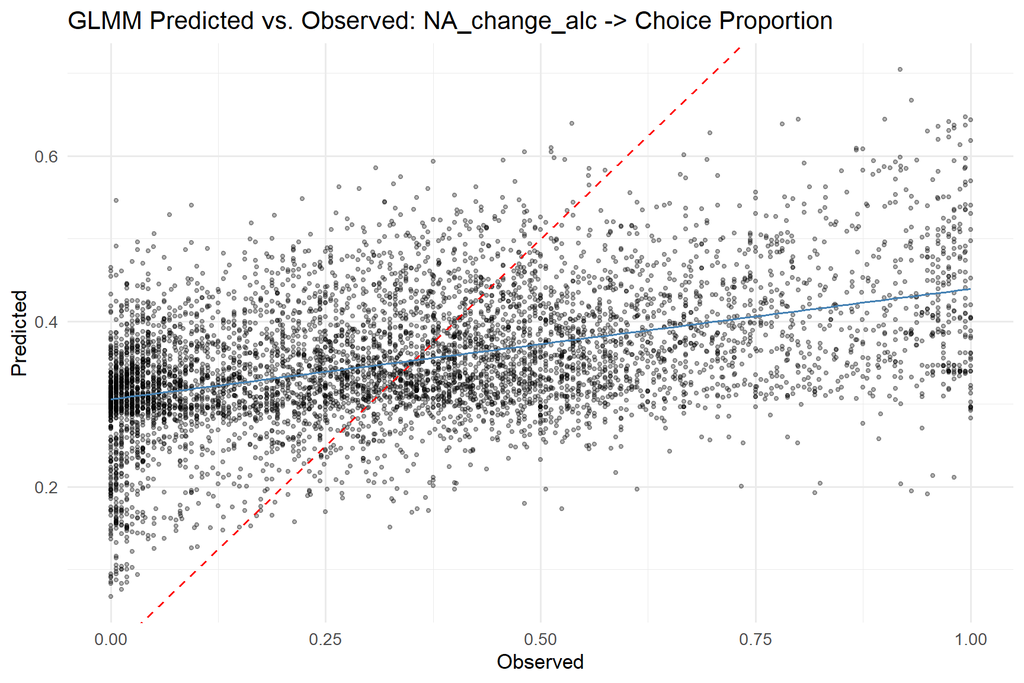

#### 3.2.1.2 Residual Diagnostics

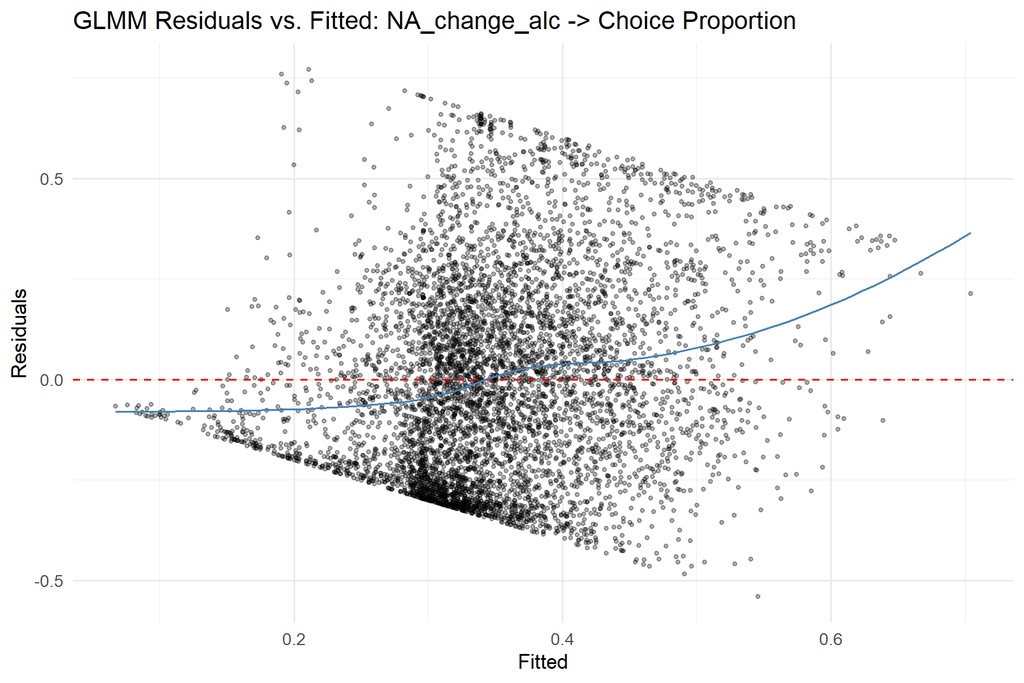

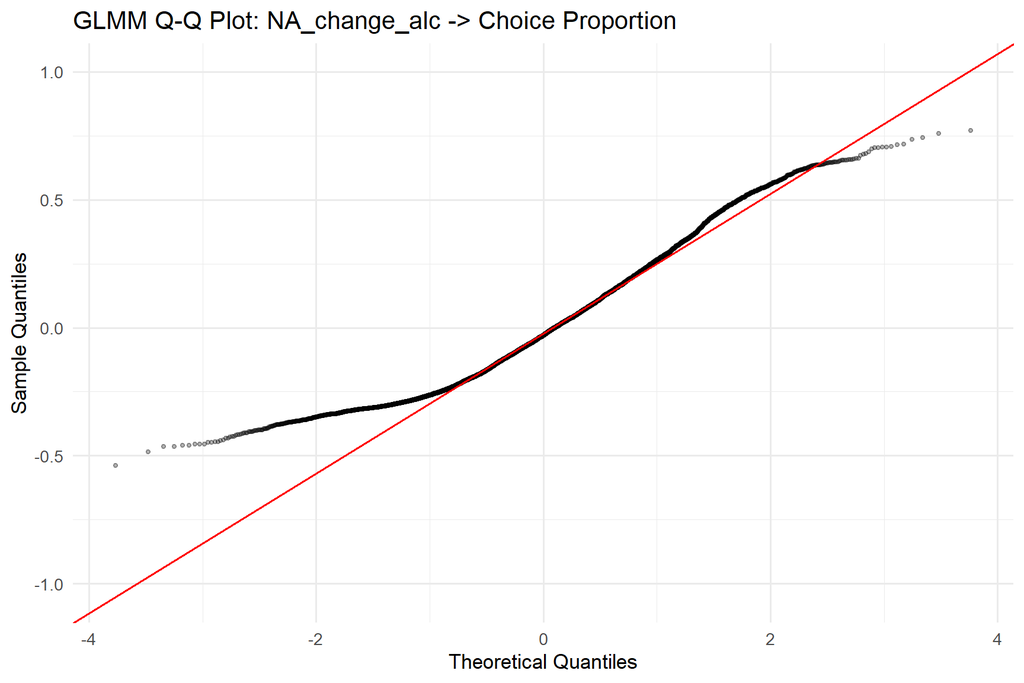

### 3.2.2 PCA Features

- **Optimal lambda:** 80 (index 5 of 21)
- **CV RMSE:** 0.2933

**Non-zero coefficients:**

| Term | Estimate |
| --- | --- |
| (Intercept) | 0.3460 |
| PC_1 | -0.0320 |
| PC_2 | 0.0463 |
| PC_3 | -0.0528 |
| PC_5 | -0.0041 |
| NA_change_alc | -0.0283 |
| PC_1:NA_change_alc | 0.0048 |
| PC_3:NA_change_alc | -0.0001 |
| PC_5:NA_change_alc | 0.0020 |

- 3 coefficients penalized to zero.*

### 3.2.3 UMAP Features

- **Optimal lambda:** 100 (index 1 of 21)
- **CV RMSE:** 0.2809

**Non-zero coefficients:**

| Term | Estimate |
| --- | --- |
| (Intercept) | 0.3391 |
| UMAP_1 | 0.0170 |
| UMAP_2 | -0.0035 |
| UMAP_3 | -0.0003 |
| UMAP_4 | -0.0215 |
| NA_change_alc | -0.0601 |
| UMAP_1:NA_change_alc | -0.0071 |
| UMAP_3:NA_change_alc | -0.0012 |
| UMAP_5:NA_change_alc | -0.0067 |

- 3 coefficients penalized to zero.*

## 3.3 Random Forest Results (Raw)

### 3.3.1 Tuning Summary

- **mtry:** 12
- **min.node.size:** 2
- **sample.fraction:** 0.809
- **CV RMSE:** 0.1905

### 3.3.2 Variable Importance (Permutation)

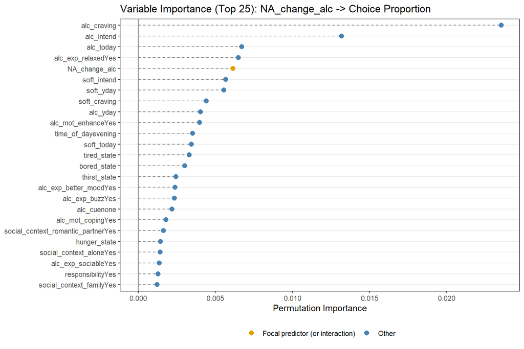

**Full importance ranking:**

| Variable | Importance |
| --- | --- |
| alc_craving | 0.023544 |
| alc_intend | 0.013170 |
| alc_today | 0.006703 |
| alc_exp_relaxedYes | 0.006489 |
| NA_change_alc | 0.006143 |
| soft_intend | 0.005670 |
| soft_yday | 0.005541 |
| soft_craving | 0.004408 |
| alc_yday | 0.004023 |
| alc_mot_enhanceYes | 0.003976 |
| time_of_dayevening | 0.003527 |
| soft_today | 0.003449 |
| tired_state | 0.003306 |
| bored_state | 0.003011 |
| thirst_state | 0.002436 |
| alc_exp_better_moodYes | 0.002377 |
| alc_exp_buzzYes | 0.002330 |
| alc_cuenone | 0.002190 |
| alc_mot_copingYes | 0.001782 |
| social_context_romantic_partnerYes | 0.001628 |
| hunger_state | 0.001426 |
| social_context_aloneYes | 0.001406 |
| alc_exp_sociableYes | 0.001358 |
| responsibilityYes | 0.001274 |
| social_context_familyYes | 0.001218 |
| locationhome | 0.000742 |
| alc_exp_embarrassedYes | 0.000713 |
| locationschool_work | 0.000590 |
| alc_exp_hangoverYes | 0.000582 |
| alc_exp_energeticYes | 0.000518 |
| alc_mot_socialYes | 0.000457 |
| alc_exp_nauseous_vomitYes | 0.000446 |
| alc_exp_be_rudeYes | 0.000370 |
| alc_exp_injuryYes | 0.000218 |
| social_context_friend_roommateYes | 0.000138 |
| locationother | 0.000135 |
| alc_cueindirectly_visible | 0.000082 |
| locationsomeone_elses_home | 0.000061 |
| social_context_strangerYes | 0.000054 |
| day_of_weekSun | 0.000041 |
| social_context_coworker_classmateYes | 0.000040 |
| day_of_weekSat | 0.000022 |
| locationoutdoors | 0.000022 |
| locationrestaurant_cafe | 0.000015 |
| social_context_otherYes | 0.000012 |
| day_of_weekWed | -0.000039 |
| day_of_weekMon | -0.000046 |
| day_of_weekTue | -0.000090 |
| day_of_weekThu | -0.000091 |

### 3.3.3 Partial Dependence Plots

PDP for the focal predictor and the top 5 most important non-interaction covariates.

#### 3.3.3.1 Focal Predictor: NA_change_alc

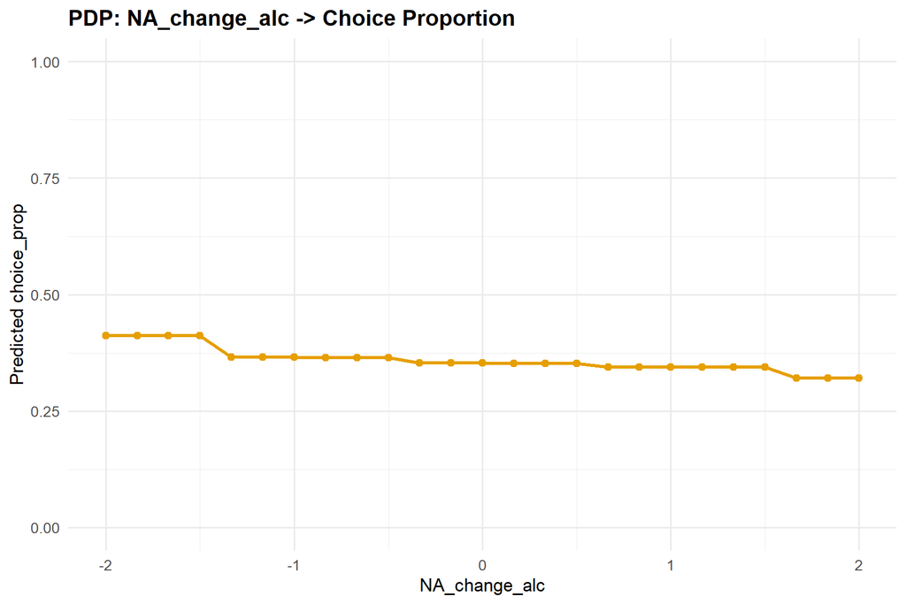

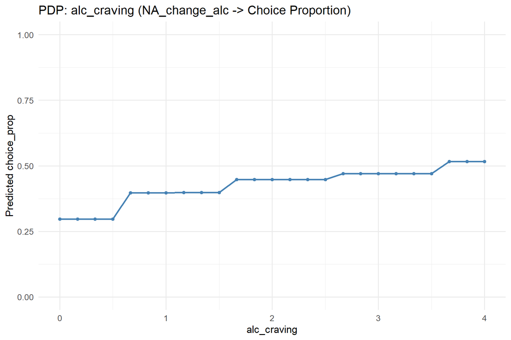

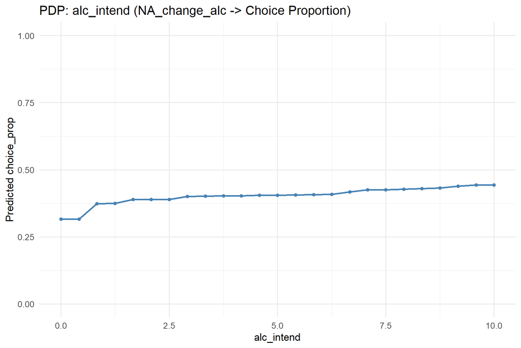

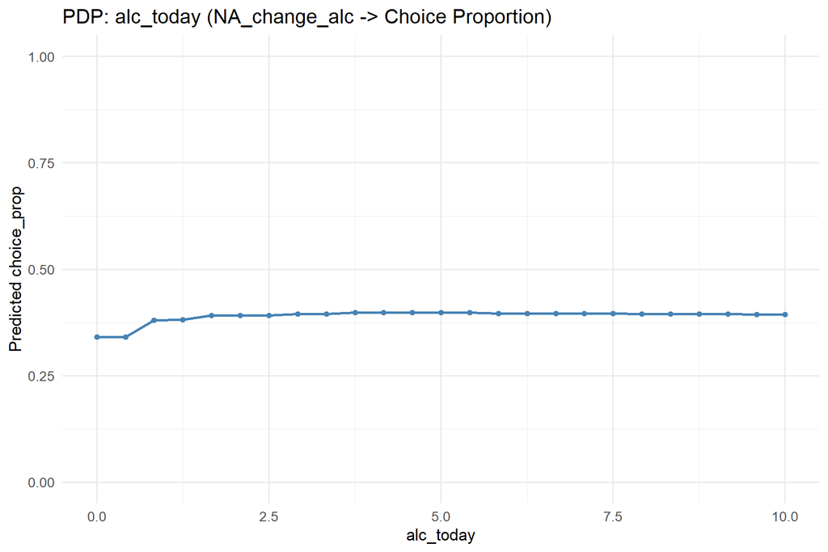

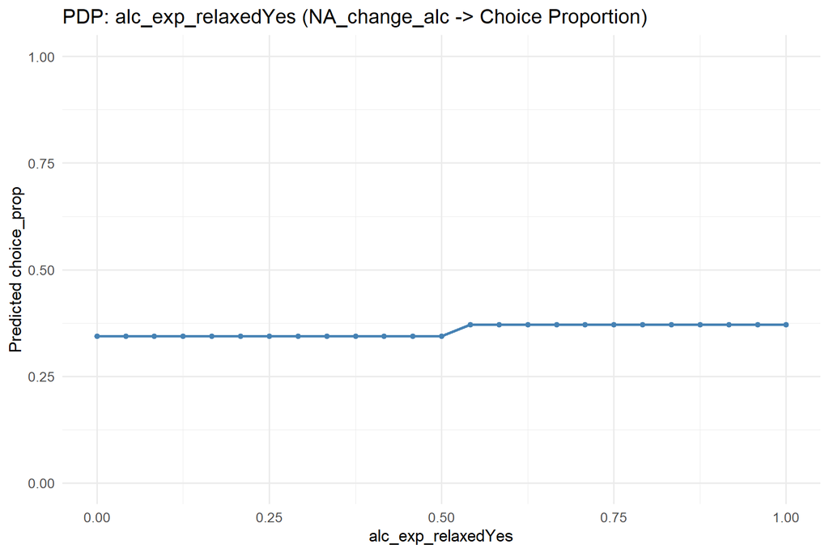

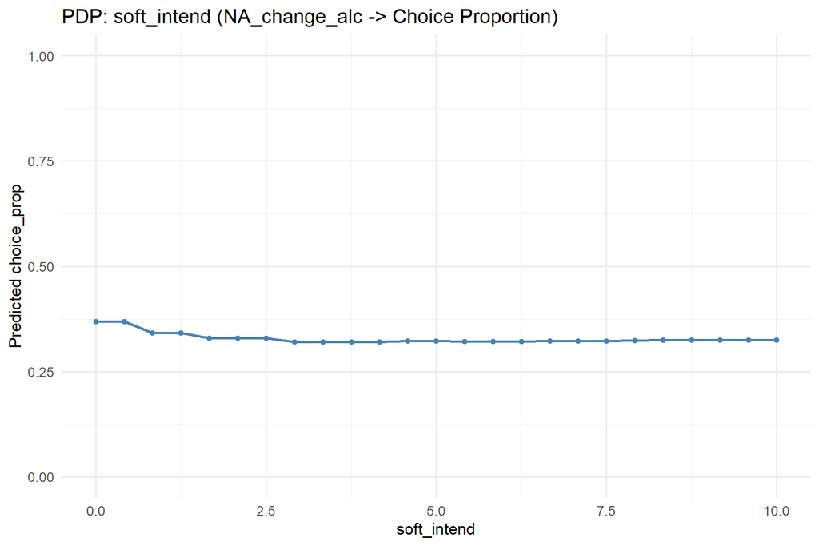

### 3.3.4 Predicted vs. Observed

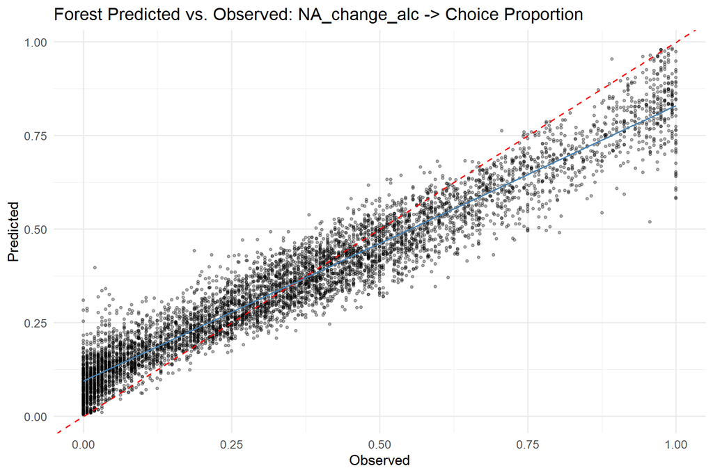

## 3.4 Model Comparison

### 3.4.1 RMSE Comparison (all methods and feature sets)

| Method | Raw | PCA | UMAP |
| --- | --- | --- | --- |
| glmm | 0.2816 | 0.2933 | 0.2809 |
| forest | 0.1905 | 0.2319 | 0.2112 |
| tree | 0.2464 | 0.2617 | 0.2642 |

# 4 Expected Positive Affect Change (with alcohol) (PA_change_alc)

## 4.1 Dimensionality Reduction

- **PCA components (80% variance, max 5):** 5
- **UMAP components (matching PCA):** 5

### 4.1.1 PCA Component Composition (top 5 correlated variables)

**PC_1**

| Variable | Correlation |
| --- | --- |
| alc_exp_energeticYes | -0.576 |
| alc_exp_better_moodYes | -0.557 |
| alc_exp_sociableYes | -0.547 |
| alc_exp_buzzYes | -0.502 |
| alc_craving | -0.487 |

**PC_2**

| Variable | Correlation |
| --- | --- |
| alc_exp_injuryYes | -0.595 |
| alc_exp_be_rudeYes | -0.593 |
| alc_exp_embarrassedYes | -0.578 |
| alc_exp_nauseous_vomitYes | -0.491 |
| alc_exp_hangoverYes | -0.468 |

**PC_3**

| Variable | Correlation |
| --- | --- |
| locationschool_work | 0.591 |
| alc_today | -0.579 |
| alc_cuenone | 0.569 |
| time_of_dayevening | -0.476 |
| locationhome | -0.458 |

**PC_4**

| Variable | Correlation |
| --- | --- |
| soft_yday | 0.699 |
| soft_today | 0.649 |
| soft_intend | 0.634 |
| soft_craving | 0.489 |
| alc_exp_embarrassedYes | -0.390 |

**PC_5**

| Variable | Correlation |
| --- | --- |
| locationhome | -0.632 |
| social_context_aloneYes | -0.561 |
| social_context_friend_roommateYes | 0.501 |
| social_context_strangerYes | 0.417 |
| locationsomeone_elses_home | 0.372 |

### 4.1.2 UMAP Component Composition (top 5 correlated variables)

**UMAP_1**

| Variable | Correlation |
| --- | --- |
| alc_yday | -0.341 |
| alc_intend | -0.300 |
| alc_craving | -0.253 |
| alc_exp_embarrassedYes | -0.160 |
| alc_exp_be_rudeYes | -0.158 |

**UMAP_2**

| Variable | Correlation |
| --- | --- |
| alc_exp_embarrassedYes | -0.307 |
| alc_exp_be_rudeYes | -0.303 |
| alc_craving | -0.228 |
| soft_yday | -0.195 |
| soft_today | -0.173 |

**UMAP_3**

| Variable | Correlation |
| --- | --- |
| alc_yday | -0.583 |
| alc_today | -0.431 |
| alc_cuenone | 0.193 |
| alc_intend | -0.175 |
| alc_exp_be_rudeYes | 0.172 |

**UMAP_4**

| Variable | Correlation |
| --- | --- |
| soft_yday | 0.871 |
| soft_today | 0.782 |
| soft_intend | 0.644 |
| soft_craving | 0.373 |
| alc_exp_be_rudeYes | 0.194 |

**UMAP_5**

| Variable | Correlation |
| --- | --- |
| alc_exp_injuryYes | -0.493 |
| alc_exp_embarrassedYes | -0.343 |
| alc_exp_be_rudeYes | -0.339 |
| alc_exp_nauseous_vomitYes | -0.339 |
| alc_exp_energeticYes | -0.220 |

## 4.2 GLMM Results

### 4.2.1 Raw Features

- **Optimal lambda:** 100 (index 1 of 21)
- **CV RMSE:** 0.2809

**Non-zero coefficients** (focal predictor terms highlighted):

| Term | Estimate | Category |
| --- | --- | --- |
| (Intercept) | 0.2920 | Intercept |
| PA_change_alc | 0.0064 | Focal predictor |
| alc_cuenone | -0.0145 | Covariate main effect |
| alc_craving | 0.0143 | Covariate main effect |
| alc_exp_nauseous_vomitYes | -0.0113 | Covariate main effect |
| alc_exp_relaxedYes | 0.0112 | Covariate main effect |
| alc_mot_enhanceYes | 0.0068 | Covariate main effect |
| time_of_dayevening | 0.0065 | Covariate main effect |
| alc_intend | 0.0055 | Covariate main effect |
| alc_exp_better_moodYes | 0.0055 | Covariate main effect |
| alc_exp_buzzYes | 0.0046 | Covariate main effect |
| alc_today | 0.0039 | Covariate main effect |
| soft_intend | -0.0025 | Covariate main effect |
| soft_craving | -0.0025 | Covariate main effect |
| alc_mot_copingYes | 0.0022 | Covariate main effect |
| alc_yday | 0.0010 | Covariate main effect |
| soft_yday | -0.0005 | Covariate main effect |
| social_context_romantic_partnerYes | 0.0005 | Covariate main effect |
| alc_exp_sociableYes | -0.0001 | Covariate main effect |
| alc_exp_energeticYes | 0.0001 | Covariate main effect |
| time_of_dayevening:PA_change_alc | 0.0145 | Interaction with focal predictor |
| alc_craving:PA_change_alc | 0.0063 | Interaction with focal predictor |
| alc_exp_buzzYes:PA_change_alc | 0.0063 | Interaction with focal predictor |
| alc_exp_relaxedYes:PA_change_alc | 0.0059 | Interaction with focal predictor |
| responsibilityYes:PA_change_alc | 0.0058 | Interaction with focal predictor |
| locationhome:PA_change_alc | 0.0056 | Interaction with focal predictor |
| alc_exp_hangoverYes:PA_change_alc | 0.0055 | Interaction with focal predictor |
| social_context_romantic_partnerYes:PA_change_alc | 0.0055 | Interaction with focal predictor |
| alc_exp_embarrassedYes:PA_change_alc | 0.0051 | Interaction with focal predictor |
| alc_exp_nauseous_vomitYes:PA_change_alc | 0.0049 | Interaction with focal predictor |
| alc_exp_better_moodYes:PA_change_alc | 0.0048 | Interaction with focal predictor |
| alc_mot_enhanceYes:PA_change_alc | 0.0046 | Interaction with focal predictor |
| social_context_aloneYes:PA_change_alc | 0.0044 | Interaction with focal predictor |
| alc_mot_copingYes:PA_change_alc | 0.0032 | Interaction with focal predictor |
| alc_today:PA_change_alc | 0.0024 | Interaction with focal predictor |
| bored_state:PA_change_alc | 0.0024 | Interaction with focal predictor |
| alc_intend:PA_change_alc | 0.0023 | Interaction with focal predictor |
| alc_exp_be_rudeYes:PA_change_alc | 0.0023 | Interaction with focal predictor |
| thirst_state:PA_change_alc | 0.0021 | Interaction with focal predictor |
| tired_state:PA_change_alc | 0.0020 | Interaction with focal predictor |
| alc_cuenone:PA_change_alc | 0.0020 | Interaction with focal predictor |
| soft_today:PA_change_alc | 0.0014 | Interaction with focal predictor |
| alc_exp_sociableYes:PA_change_alc | 0.0009 | Interaction with focal predictor |
| alc_exp_energeticYes:PA_change_alc | 0.0009 | Interaction with focal predictor |
| alc_yday:PA_change_alc | 0.0008 | Interaction with focal predictor |
| soft_yday:PA_change_alc | 0.0007 | Interaction with focal predictor |
| day_of_weekMon:PA_change_alc | 0.0007 | Interaction with focal predictor |
| hunger_state:PA_change_alc | 0.0003 | Interaction with focal predictor |
| soft_craving:PA_change_alc | -0.0003 | Interaction with focal predictor |
| social_context_friend_roommateYes:PA_change_alc | 0.0003 | Interaction with focal predictor |
| locationother:PA_change_alc | 0.0002 | Interaction with focal predictor |
| day_of_weekSat:PA_change_alc | 0.0002 | Interaction with focal predictor |
| alc_exp_injuryYes:PA_change_alc | 0.0001 | Interaction with focal predictor |
| social_context_familyYes:PA_change_alc | 0.0001 | Interaction with focal predictor |
| day_of_weekSun:PA_change_alc | -0.0001 | Interaction with focal predictor |
| day_of_weekTue:PA_change_alc | -0.0001 | Interaction with focal predictor |

- 42 coefficients penalized to zero.*

#### 4.2.1.1 Predicted vs. Observed

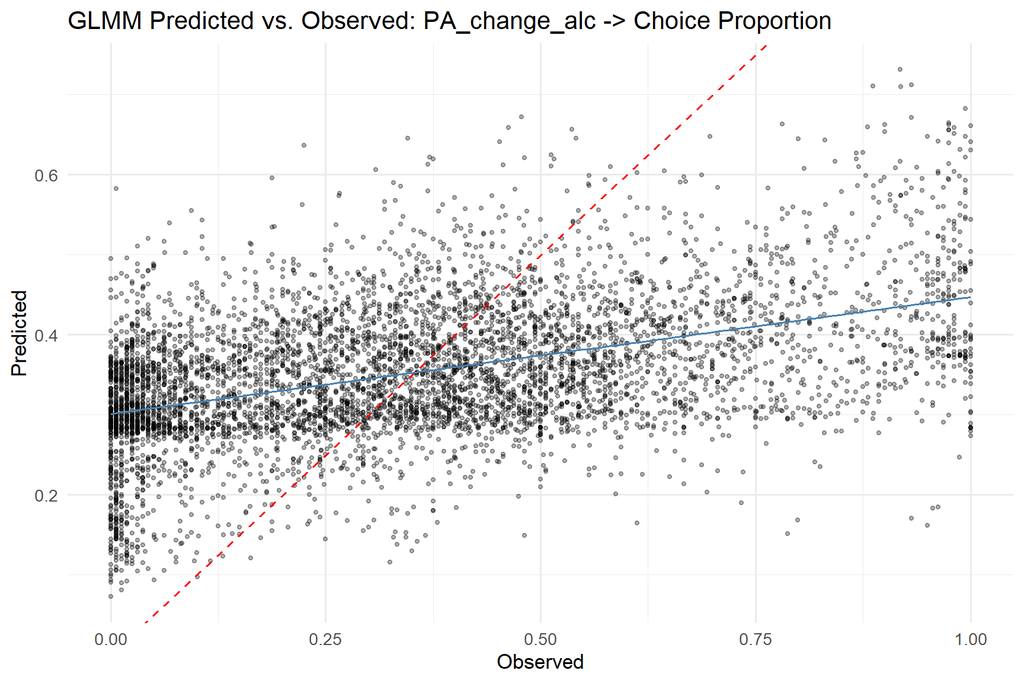

#### 4.2.1.2 Residual Diagnostics

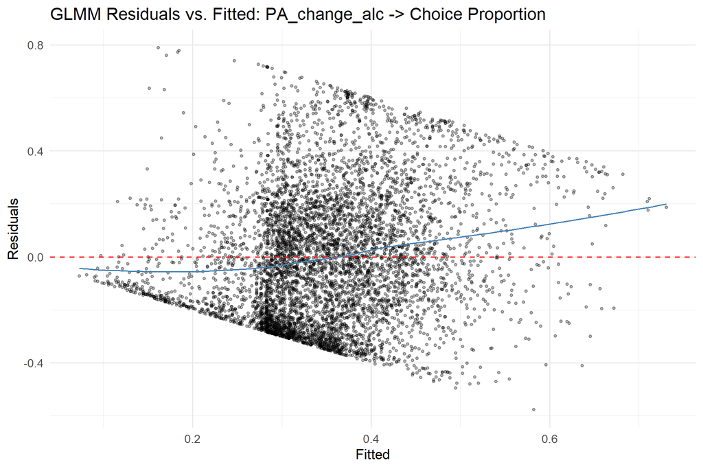

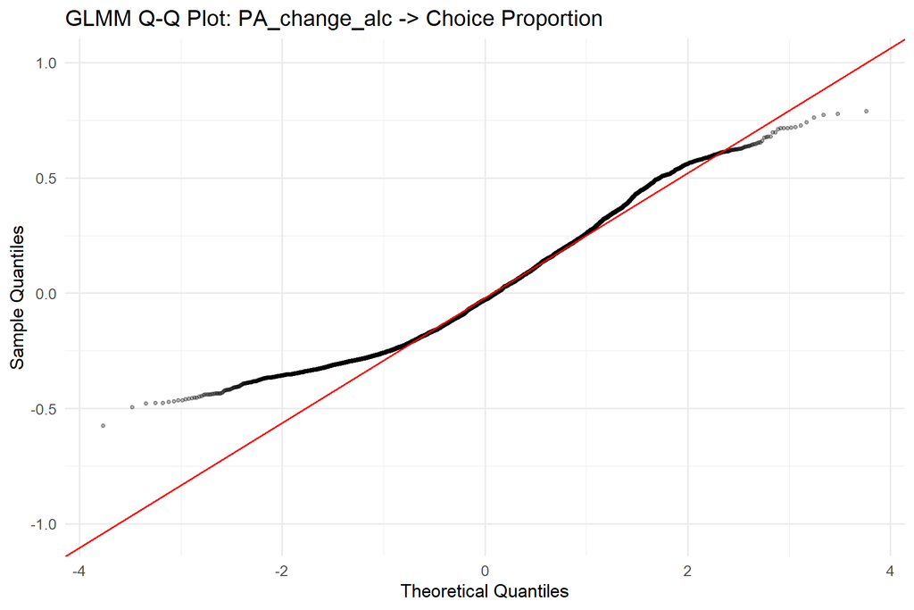

### 4.2.2 PCA Features

- **Optimal lambda:** 80 (index 5 of 21)
- **CV RMSE:** 0.3155

**Non-zero coefficients:**

| Term | Estimate |
| --- | --- |
| (Intercept) | 0.3319 |
| PC_1 | -0.0234 |
| PC_2 | 0.0411 |
| PC_3 | -0.0455 |
| PC_5 | -0.0019 |
| PA_change_alc | 0.0431 |
| PC_1:PA_change_alc | -0.0006 |
| PC_3:PA_change_alc | -0.0063 |
| PC_5:PA_change_alc | -0.0047 |

- 3 coefficients penalized to zero.*

### 4.2.3 UMAP Features

- **Optimal lambda:** 75 (index 6 of 21)
- **CV RMSE:** 0.2867

**Non-zero coefficients:**

| Term | Estimate |
| --- | --- |
| (Intercept) | 0.3223 |
| UMAP_1 | -0.0236 |
| UMAP_2 | -0.0033 |
| UMAP_3 | -0.0074 |
| UMAP_4 | -0.0098 |
| PA_change_alc | 0.0679 |
| UMAP_1:PA_change_alc | -0.0042 |
| UMAP_2:PA_change_alc | -0.0102 |
| UMAP_5:PA_change_alc | -0.0039 |

- 3 coefficients penalized to zero.*

## 4.3 Random Forest Results (Raw)

### 4.3.1 Tuning Summary

- **mtry:** 12
- **min.node.size:** 2
- **sample.fraction:** 0.801
- **CV RMSE:** 0.1907

### 4.3.2 Variable Importance (Permutation)

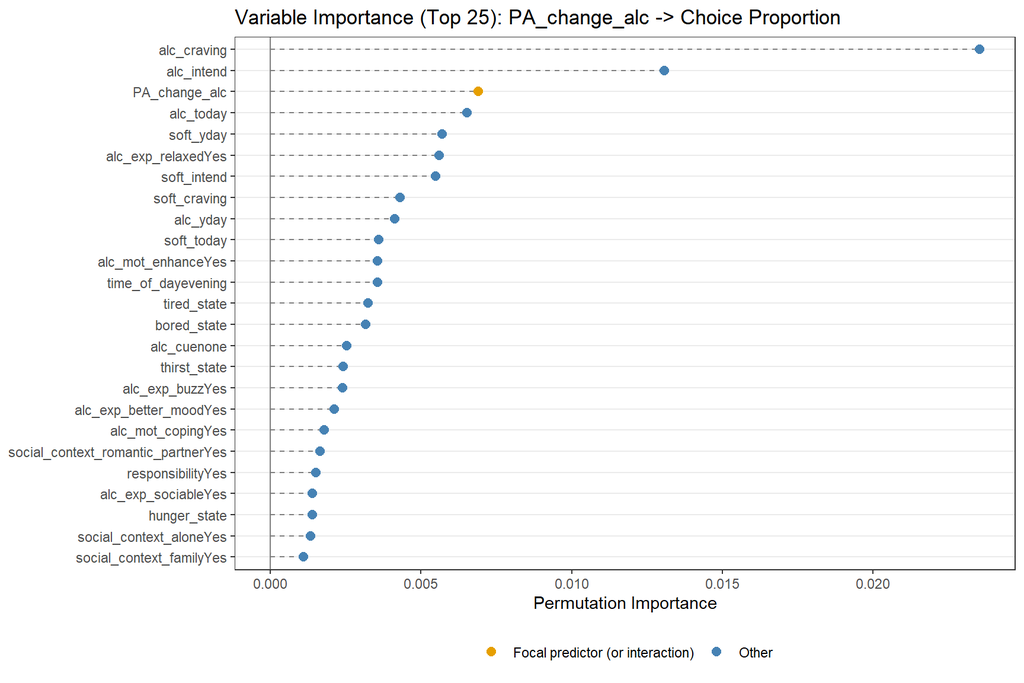

**Full importance ranking:**

| Variable | Importance |
| --- | --- |
| alc_craving | 0.023534 |
| alc_intend | 0.013068 |
| PA_change_alc | 0.006902 |
| alc_today | 0.006524 |
| soft_yday | 0.005692 |
| alc_exp_relaxedYes | 0.005598 |
| soft_intend | 0.005487 |
| soft_craving | 0.004295 |
| alc_yday | 0.004126 |
| soft_today | 0.003599 |
| alc_mot_enhanceYes | 0.003553 |
| time_of_dayevening | 0.003552 |
| tired_state | 0.003247 |
| bored_state | 0.003169 |
| alc_cuenone | 0.002544 |
| thirst_state | 0.002413 |
| alc_exp_buzzYes | 0.002390 |
| alc_exp_better_moodYes | 0.002118 |
| alc_mot_copingYes | 0.001795 |
| social_context_romantic_partnerYes | 0.001652 |
| responsibilityYes | 0.001512 |
| alc_exp_sociableYes | 0.001397 |
| hunger_state | 0.001393 |
| social_context_aloneYes | 0.001343 |
| social_context_familyYes | 0.001098 |
| locationhome | 0.000725 |
| alc_exp_embarrassedYes | 0.000719 |
| alc_exp_energeticYes | 0.000624 |
| alc_exp_hangoverYes | 0.000621 |
| locationschool_work | 0.000580 |
| alc_exp_be_rudeYes | 0.000432 |
| alc_mot_socialYes | 0.000394 |
| alc_exp_nauseous_vomitYes | 0.000370 |
| alc_exp_injuryYes | 0.000229 |
| locationother | 0.000176 |
| social_context_friend_roommateYes | 0.000125 |
| social_context_coworker_classmateYes | 0.000081 |
| alc_cueindirectly_visible | 0.000079 |
| locationsomeone_elses_home | 0.000052 |
| day_of_weekSun | 0.000042 |
| social_context_strangerYes | 0.000038 |
| locationrestaurant_cafe | 0.000026 |
| locationoutdoors | 0.000024 |
| day_of_weekSat | 0.000015 |
| social_context_otherYes | 0.000008 |
| day_of_weekThu | -0.000059 |
| day_of_weekWed | -0.000082 |
| day_of_weekMon | -0.000085 |
| day_of_weekTue | -0.000125 |

### 4.3.3 Partial Dependence Plots

PDP for the focal predictor and the top 5 most important non-interaction covariates.

#### 4.3.3.1 Focal Predictor: PA_change_alc

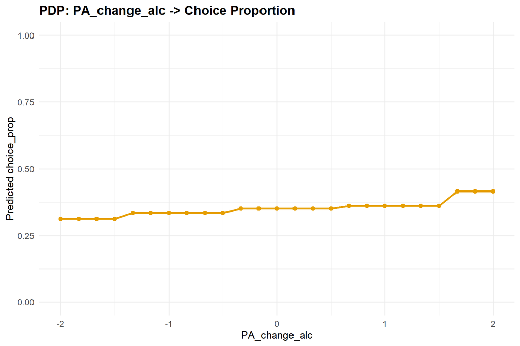

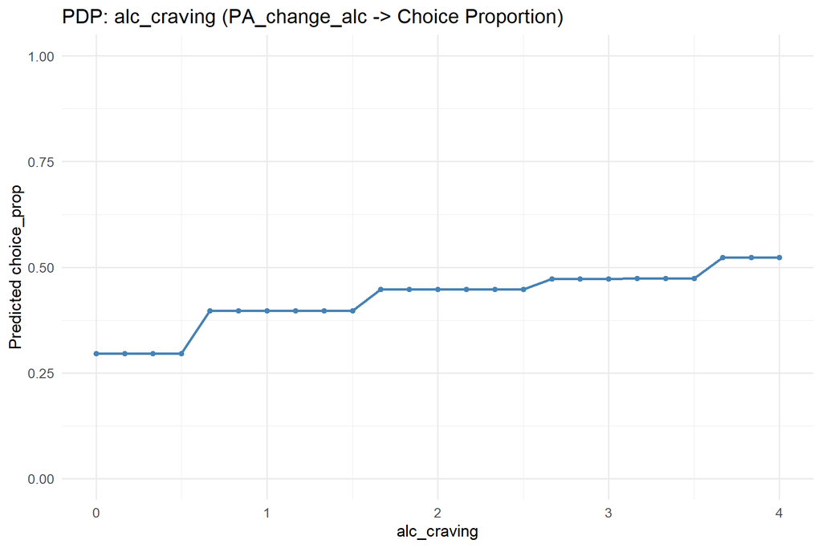

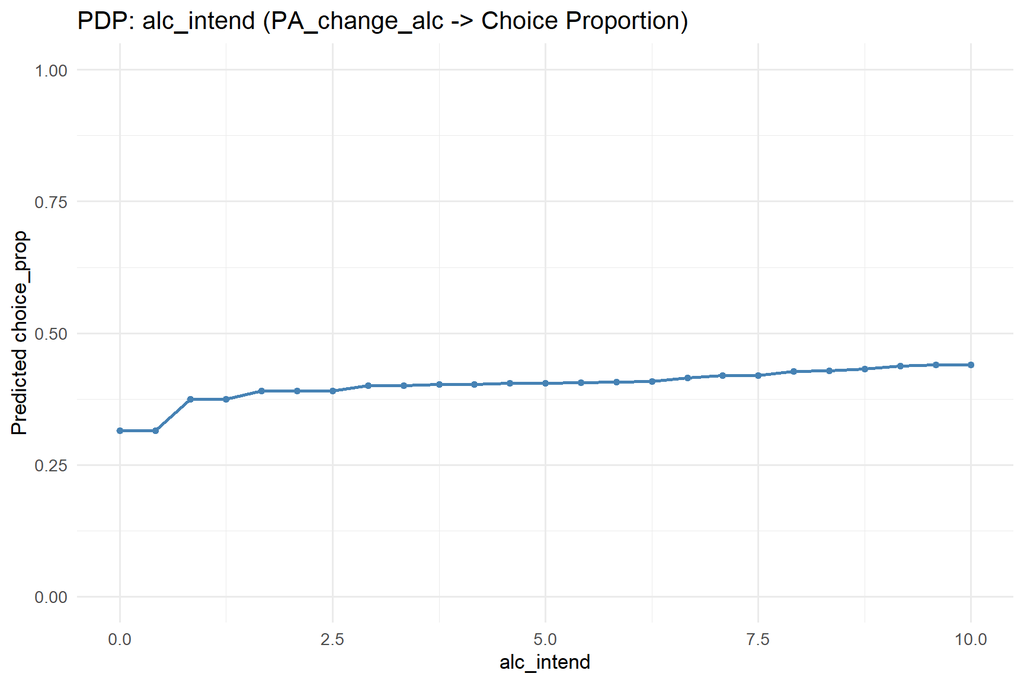

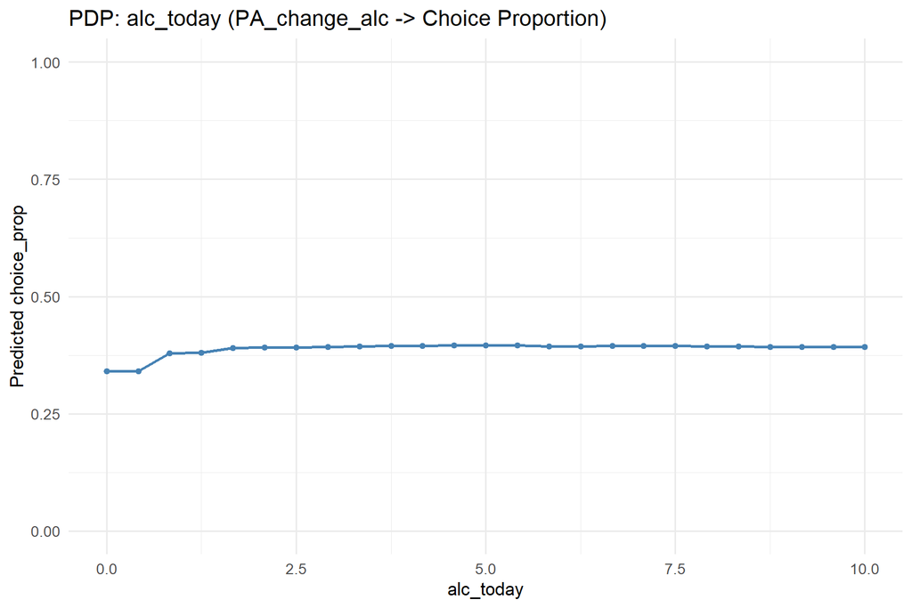

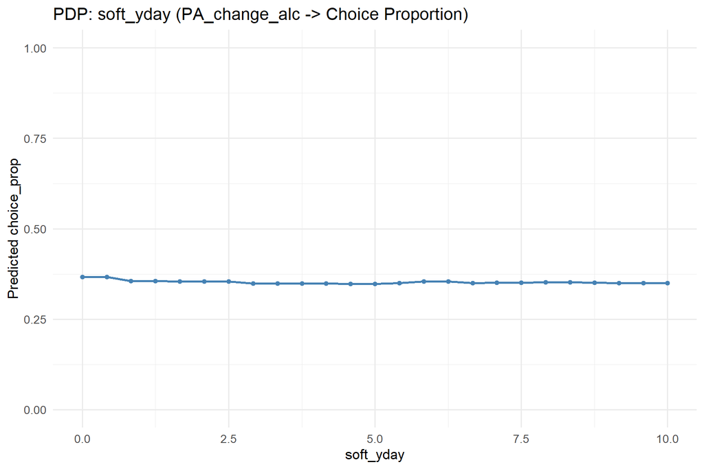

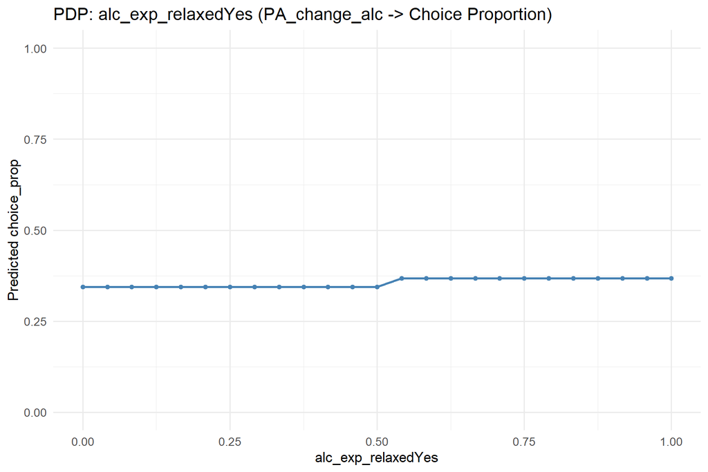